# DATA_606 Final Presentation

Bikram Barua

12/7/2021

# Abstract

From high tides to crazy moods, the full moon is believed to cause a number of things. As the full moon approaches, full-term pregnant womean everywhere prepare hopefully to go into labor. Is this an old wives tales or something mysterious that we hear plenty about, but don’t yet understand?

There is no evidence to such a phenomenon. This study is based to look into the birth data in US and attempt to link them with to full moons to see if there is any correlation. We will first try to identify some good data sources for the study. Based on the data, it will be filtered, formatted and grouped into appropriate categories for the study.

The prepared data will then be processed using statistical methods to reveal the facts around the myth and understand the rationality of the belief which has been around for a very, very long time. Many cultures around the world hold strong beliefs in this link and the folklore tends to stretch back forever.

# Introduction

### Myth or Fact: Do more Women Go into labor During a Full Moon ?

Compare the birth counts on regular days with the full moon days.  
Do you see any difference? Can we draw any inference based on the data?

Null Hypothesis: There is no effect of Full Moon with Women going into Labor and child being born.

Alternate Hypothesis: Women go into Labor due to Full Moon, there are more births on full moon nights.

Below is the reference to an article on this topic:  
_Ref: https://www.dukehealth.org/blog/myth-or-fact-more-women-go-labor-during-full-moon_

US births from 2000-2014, data source: [fivethirtyeight.com](https://github.com/fivethirtyeight/data/blob/master/births/US_births_2000-2014_SSA.csv)

Time series of full moon occurrences, data source: [Kaggle](https://www.kaggle.com/lsind18/full-moon-calendar-1900-2050).

# US Birth Data

| year | month | date_of_month | day_of_week | births |
| --- | --- | --- | --- | --- |
| 2000 | 1 | 1 | 6 | 9083 |
| 2000 | 1 | 2 | 7 | 8006 |
| 2000 | 1 | 3 | 1 | 11363 |
| 2000 | 1 | 4 | 2 | 13032 |
| 2000 | 1 | 5 | 3 | 12558 |
| 2000 | 1 | 6 | 4 | 12466 |
| 2000 | 1 | 7 | 5 | 12516 |
| 2000 | 1 | 8 | 6 | 8934 |
| 2000 | 1 | 9 | 7 | 7949 |
| 2000 | 1 | 10 | 1 | 11668 |
| 2000 | 1 | 11 | 2 | 12611 |
| 2000 | 1 | 12 | 3 | 12398 |
| 2000 | 1 | 13 | 4 | 11815 |
| 2000 | 1 | 14 | 5 | 12180 |
| 2000 | 1 | 15 | 6 | 8525 |
| 2000 | 1 | 16 | 7 | 7657 |
| 2000 | 1 | 17 | 1 | 10824 |
| 2000 | 1 | 18 | 2 | 12350 |
| 2000 | 1 | 19 | 3 | 12405 |
| 2000 | 1 | 20 | 4 | 12506 |

# Full Moon Days

| Day | Date |
| --- | --- |
| Monday | 15 January 1900 |
| Wednesday | 14 February 1900 |
| Friday | 16 March 1900 |
| Sunday | 15 April 1900 |
| Monday | 14 May 1900 |
| Wednesday | 13 June 1900 |
| Thursday | 12 July 1900 |
| Friday | 10 August 1900 |
| Sunday | 9 September 1900 |
| Monday | 8 October 1900 |
| Tuesday | 6 November 1900 |
| Thursday | 6 December 1900 |
| Saturday | 5 January 1901 |
| Sunday | 3 February 1901 |
| Tuesday | 5 March 1901 |
| Thursday | 4 April 1901 |
| Friday | 3 May 1901 |
| Sunday | 2 June 1901 |
| Tuesday | 2 July 1901 |
| Wednesday | 31 July 1901 |

# Format Full Moon Data

### Split Date description into Date, Month and Year

| FM_Day | FM_Full_Date | FM_Date | FM_Month | FM_Year |
| --- | --- | --- | --- | --- |
| Monday | 15 January 1900 | 15 | 1 | 1900 |
| Wednesday | 14 February 1900 | 14 | 2 | 1900 |
| Friday | 16 March 1900 | 16 | 3 | 1900 |
| Sunday | 15 April 1900 | 15 | 4 | 1900 |
| Monday | 14 May 1900 | 14 | 5 | 1900 |
| Wednesday | 13 June 1900 | 13 | 6 | 1900 |
| Thursday | 12 July 1900 | 12 | 7 | 1900 |
| Friday | 10 August 1900 | 10 | 8 | 1900 |
| Sunday | 9 September 1900 | 9 | 9 | 1900 |
| Monday | 8 October 1900 | 8 | 10 | 1900 |
| Tuesday | 6 November 1900 | 6 | 11 | 1900 |
| Thursday | 6 December 1900 | 6 | 12 | 1900 |
| Saturday | 5 January 1901 | 5 | 1 | 1901 |
| Sunday | 3 February 1901 | 3 | 2 | 1901 |
| Tuesday | 5 March 1901 | 5 | 3 | 1901 |

# Highest Birth Count By Year (Top 6)

### Group By Year, Sum and Sort

| year | sum |
| --- | --- |
| 2007 | 4380784 |
| 2006 | 4335154 |
| 2008 | 4310737 |
| 2005 | 4211941 |
| 2009 | 4190991 |
| 2004 | 4186863 |

# 2007 birth count by month

| month | mean |
| --- | --- |
| 1 | 11629.71 |
| 2 | 11843.46 |
| 3 | 11802.84 |
| 4 | 11432.70 |
| 5 | 11854.55 |
| 6 | 12116.20 |
| 7 | 12414.87 |
| 8 | 12785.65 |
| 9 | 12425.80 |
| 10 | 12105.55 |
| 11 | 11977.83 |
| 12 | 11619.45 |

```
## [1] "Total Births(mean) in 2007 is 144008.61"
```

```
## [1] "Mean Birth per day in 2007 is 12000.72"
```

# Full Moon Births in 2007

| year | month | date_of_month | day_of_week | births | FM_Day | FM_Full_Date |
| --- | --- | --- | --- | --- | --- | --- |
| 2007 | 1 | 3 | 3 | 13687 | Wednesday | 3 January 2007 |
| 2007 | 2 | 2 | 5 | 13305 | Friday | 2 February 2007 |
| 2007 | 3 | 4 | 7 | 7566 | Sunday | 4 March 2007 |
| 2007 | 4 | 2 | 1 | 12450 | Monday | 2 April 2007 |
| 2007 | 5 | 2 | 3 | 13325 | Wednesday | 2 May 2007 |
| 2007 | 6 | 1 | 5 | 13714 | Friday | 1 June 2007 |
| 2007 | 6 | 30 | 6 | 9016 | Saturday | 30 June 2007 |
| 2007 | 7 | 30 | 1 | 13439 | Monday | 30 July 2007 |
| 2007 | 8 | 28 | 2 | 14959 | Tuesday | 28 August 2007 |
| 2007 | 9 | 26 | 3 | 14417 | Wednesday | 26 September 2007 |
| 2007 | 10 | 26 | 5 | 13223 | Friday | 26 October 2007 |
| 2007 | 11 | 24 | 6 | 8380 | Saturday | 24 November 2007 |
| 2007 | 12 | 24 | 1 | 7727 | Monday | 24 December 2007 |

[output not shown]

# Merge and Compare the births counts (Regular vs Full Moon)

### One of the most common statistical tasks is to compare an outcome between two groups.

| month | mean | year | date_of_month | day_of_week | births | FM_Day | FM_Full_Date |
| --- | --- | --- | --- | --- | --- | --- | --- |
| 1 | 11629.71 | 2007 | 3 | 3 | 13687 | Wednesday | 3 January 2007 |
| 2 | 11843.46 | 2007 | 2 | 5 | 13305 | Friday | 2 February 2007 |
| 3 | 11802.84 | 2007 | 4 | 7 | 7566 | Sunday | 4 March 2007 |
| 4 | 11432.70 | 2007 | 2 | 1 | 12450 | Monday | 2 April 2007 |
| 5 | 11854.55 | 2007 | 2 | 3 | 13325 | Wednesday | 2 May 2007 |
| 6 | 12116.20 | 2007 | 1 | 5 | 13714 | Friday | 1 June 2007 |
| 6 | 12116.20 | 2007 | 30 | 6 | 9016 | Saturday | 30 June 2007 |
| 7 | 12414.87 | 2007 | 30 | 1 | 13439 | Monday | 30 July 2007 |
| 8 | 12785.65 | 2007 | 28 | 2 | 14959 | Tuesday | 28 August 2007 |
| 9 | 12425.80 | 2007 | 26 | 3 | 14417 | Wednesday | 26 September 2007 |
| 10 | 12105.55 | 2007 | 26 | 5 | 13223 | Friday | 26 October 2007 |
| 11 | 11977.83 | 2007 | 24 | 6 | 8380 | Saturday | 24 November 2007 |
| 12 | 11619.45 | 2007 | 24 | 1 | 7727 | Monday | 24 December 2007 |

# Plot 2007 regular births and full moon births

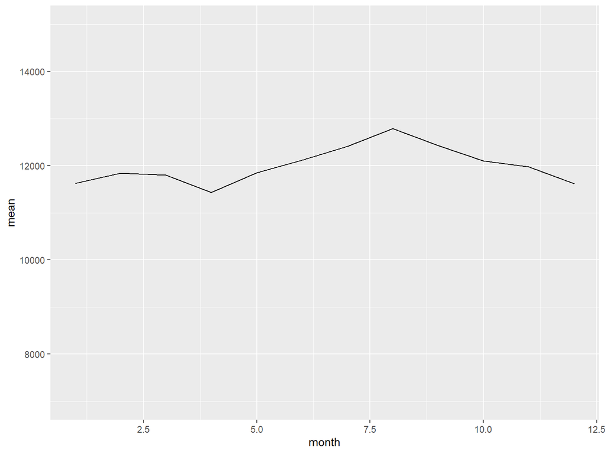

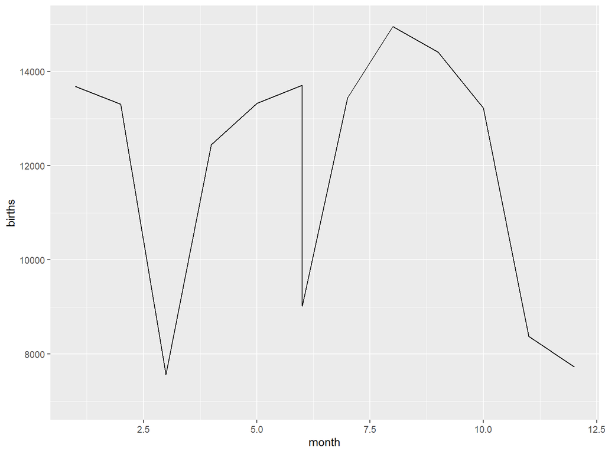

# T-Test Analysis

```r
birth.t.test <- t.test(merge_by_month_data_2007$mean, merge_by_month_data_2007$births, data = merge_by_month_data_2007)
birth.t.test
```

```
##
##  Welch Two Sample t-test
##
## data:  merge_by_month_data_2007$mean and merge_by_month_data_2007$births
## t = 0.093272, df = 12.465, p-value = 0.9272
## alternative hypothesis: true difference in means is not equal to 0
## 95 percent confidence interval:
##  -1570.097  1711.144
## sample estimates:
## mean of x mean of y
##  12009.60  11939.08
```

```r
# p-value
birth.t.test$p.value
```

```
## [1] 0.9271695
```

```r
# confidence interval
birth.t.test$conf.int
```

```
## [1] -1570.097  1711.144
## attr(,"conf.level")
## [1] 0.95
```

### High p-values indicate that the evidence is not strong enough to suggest an effect exists. It’s possible that the sample size is too small for the hypothesis test to detect it.

### Lets try to increase the sample size and run the analysis again.

# Birth data sample(2000 - 2013)

### Birth count by month

| year | month | mean |
| --- | --- | --- |
| 2000 | 1 | 10894.81 |
| 2000 | 2 | 11174.00 |
| 2000 | 3 | 11220.13 |
| 2000 | 4 | 10778.57 |
| 2000 | 5 | 11224.19 |
| 2000 | 6 | 11596.63 |

```
## [1] "Sum of Births(mean) in 2000-2013 is 1911016.25"
```

```
## [1] "Mean Birth per day in 2000-2013 is 11375.10"
```

# Full Moon Births (2000-2013)

| year | month | date_of_month | day_of_week | births | FM_Day | FM_Full_Date |
| --- | --- | --- | --- | --- | --- | --- |
| 2000 | 1 | 21 | 5 | 11953 | Friday | 21 January 2000 |
| 2000 | 2 | 19 | 6 | 8861 | Saturday | 19 February 2000 |
| 2000 | 3 | 20 | 1 | 11595 | Monday | 20 March 2000 |
| 2000 | 4 | 18 | 2 | 12783 | Tuesday | 18 April 2000 |
| 2000 | 5 | 18 | 4 | 12580 | Thursday | 18 May 2000 |
| 2000 | 6 | 17 | 6 | 9143 | Saturday | 17 June 2000 |
| 2000 | 7 | 16 | 7 | 8423 | Sunday | 16 July 2000 |
| 2000 | 8 | 15 | 2 | 13374 | Tuesday | 15 August 2000 |
| 2000 | 9 | 13 | 3 | 13299 | Wednesday | 13 September 2000 |
| 2000 | 10 | 13 | 5 | 11723 | Friday | 13 October 2000 |
| 2000 | 11 | 11 | 6 | 9318 | Saturday | 11 November 2000 |
| 2000 | 12 | 11 | 1 | 11811 | Monday | 11 December 2000 |
| 2001 | 1 | 9 | 2 | 12386 | Tuesday | 9 January 2001 |
| 2001 | 2 | 8 | 4 | 12390 | Thursday | 8 February 2001 |
| 2001 | 3 | 9 | 5 | 12461 | Friday | 9 March 2001 |

[output not shown]

# Merge and Compare data

### One of the most common statistical tasks is to compare an outcome between two groups.

| year | month | mean | date_of_month | day_of_week | births | FM_Day | FM_Full_Date |
| --- | --- | --- | --- | --- | --- | --- | --- |
| 2000 | 1 | 10894.81 | 21 | 5 | 11953 | Friday | 21 January 2000 |
| 2000 | 2 | 11174.00 | 19 | 6 | 8861 | Saturday | 19 February 2000 |
| 2000 | 3 | 11220.13 | 20 | 1 | 11595 | Monday | 20 March 2000 |
| 2000 | 4 | 10778.57 | 18 | 2 | 12783 | Tuesday | 18 April 2000 |
| 2000 | 5 | 11224.19 | 18 | 4 | 12580 | Thursday | 18 May 2000 |
| 2000 | 6 | 11596.63 | 17 | 6 | 9143 | Saturday | 17 June 2000 |
| 2000 | 7 | 11488.10 | 16 | 7 | 8423 | Sunday | 16 July 2000 |
| 2000 | 8 | 11867.52 | 15 | 2 | 13374 | Tuesday | 15 August 2000 |
| 2000 | 9 | 11866.03 | 13 | 3 | 13299 | Wednesday | 13 September 2000 |
| 2000 | 10 | 11366.71 | 13 | 5 | 11723 | Friday | 13 October 2000 |
| 2000 | 11 | 11416.47 | 11 | 6 | 9318 | Saturday | 11 November 2000 |
| 2000 | 12 | 11158.58 | 11 | 1 | 11811 | Monday | 11 December 2000 |
| 2001 | 1 | 11044.48 | 9 | 2 | 12386 | Tuesday | 9 January 2001 |
| 2001 | 2 | 11064.96 | 8 | 4 | 12390 | Thursday | 8 February 2001 |
| 2001 | 3 | 11140.16 | 9 | 5 | 12461 | Friday | 9 March 2001 |
| 2001 | 4 | 10996.13 | 8 | 7 | 7718 | Sunday | 8 April 2001 |
| 2001 | 5 | 11312.55 | 7 | 1 | 11635 | Monday | 7 May 2001 |
| 2001 | 6 | 11253.53 | 6 | 3 | 12804 | Wednesday | 6 June 2001 |
| 2001 | 7 | 11550.94 | 5 | 4 | 12531 | Thursday | 5 July 2001 |
| 2001 | 8 | 11915.58 | 4 | 6 | 9143 | Saturday | 4 August 2001 |
| 2001 | 9 | 11666.27 | 2 | 7 | 8239 | Sunday | 2 September 2001 |
| 2001 | 10 | 11350.06 | 2 | 2 | 13523 | Tuesday | 2 October 2001 |
| 2001 | 11 | 11042.53 | 1 | 4 | 12879 | Thursday | 1 November 2001 |
| 2001 | 11 | 11042.53 | 30 | 5 | 12019 | Friday | 30 November 2001 |
| 2001 | 12 | 10795.58 | 30 | 7 | 7840 | Sunday | 30 December 2001 |
| 2002 | 1 | 10886.19 | 28 | 1 | 11354 | Monday | 28 January 2002 |
| 2002 | 2 | 11068.21 | 27 | 3 | 12303 | Wednesday | 27 February 2002 |
| 2002 | 3 | 10882.23 | 28 | 4 | 12454 | Thursday | 28 March 2002 |
| 2002 | 4 | 11009.63 | 27 | 6 | 8243 | Saturday | 27 April 2002 |
| 2002 | 5 | 11124.23 | 26 | 7 | 7282 | Sunday | 26 May 2002 |

[output cut: 143 more lines]

# T-Test Analysis

```
##
##  Welch Two Sample t-test
##
## data:  merge_by_monthyear_data_bigset$mean and merge_by_monthyear_data_bigset$births
## t = -0.34611, df = 187.91, p-value = 0.7297
## alternative hypothesis: true difference in means is not equal to 0
## 95 percent confidence interval:
##  -423.1707  296.8438
## sample estimates:
## mean of x mean of y
##  11381.14  11444.31
```

# T-Test Results

```r
# p-value
birth.2t.test$p.value
```

```
## [1] 0.7296505
```

```r
# confidence interval
birth.2t.test$conf.int
```

```
## [1] -423.1707  296.8438
## attr(,"conf.level")
## [1] 0.95
```

### Based on the T-Test the p-value is 0.729, which is a large value indicating weak evidence against the null hypothesis, so fail to reject it.

# Data Visualization

### Histogram of the average births

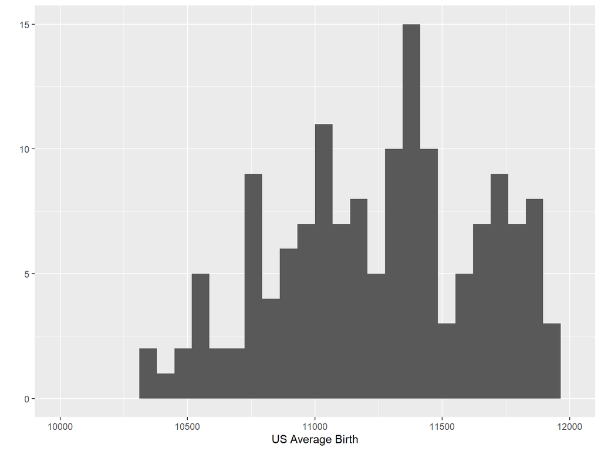

# Data Visualization

### Histogram of the full moon births

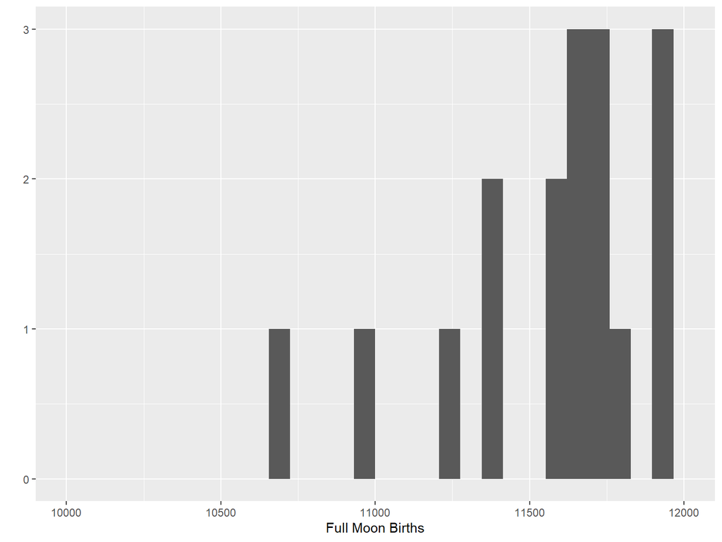

# Scatterplot of average births by month

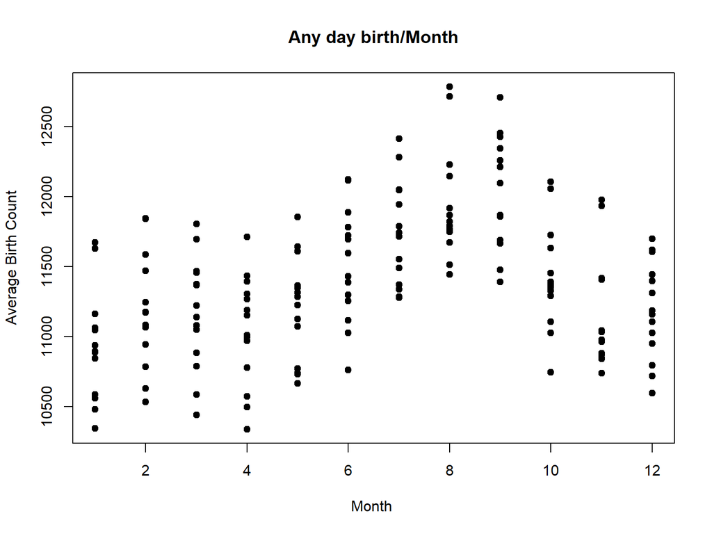

# Scatterplot of Full Moon births by month

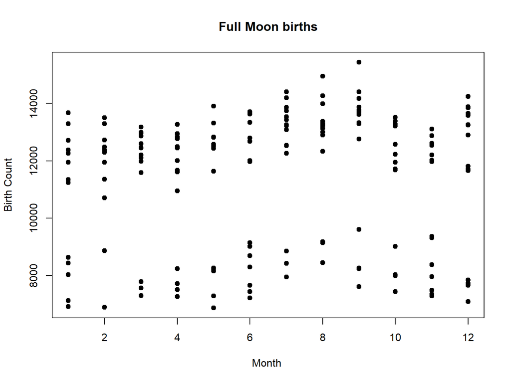

# Scatterplot the births on any day of the week

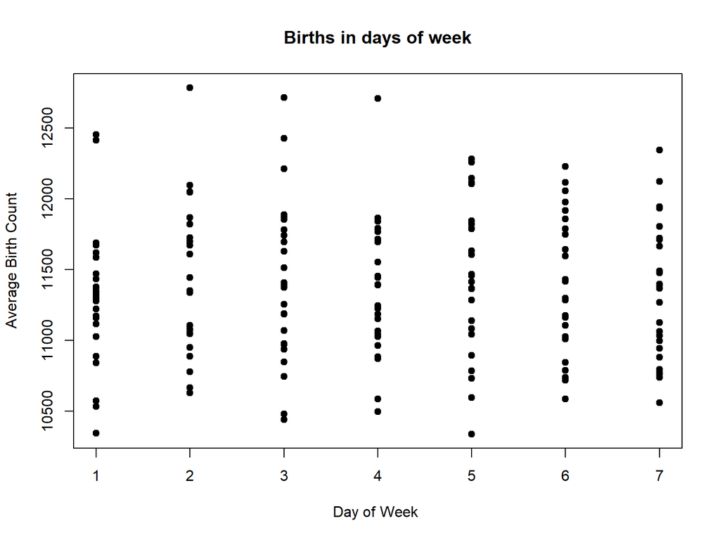

# Scatterplot the full moon births by day of the week

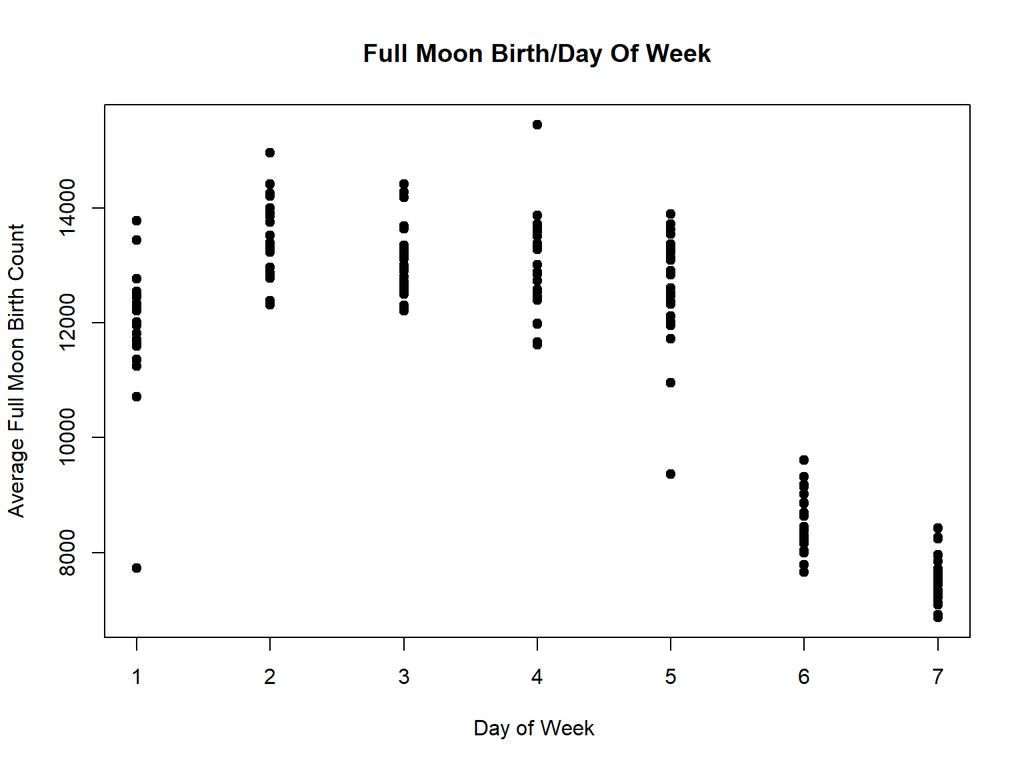

# Conclusion

This can be looked into and studied further by using other statistical methods and/or adding other variables for analysis of this cultural myth, hoping to reveal the facts and understand its nature.